# Analysis of ATAC-seq data in R and Bioconductor - Part2

Rockefeller University, Bioinformatics Resource Centre

http://rockefelleruniversity.github.io/RU_ATACseq/

# Greenleaf dataset characterisation and open region finding.

In this section we will work a little more with the Greenleaf dataset.

We will characterise Greenleaf data signal around TSS regions and identify and annotated open regions as peak calls using MACS2.

At the end of the session we will look at plotting transposase cut-sites around DNA binding proteins.

# Encode dataset characterisation and open region finding.

In this session we will also take some of the Encode data for Liver, Kidney and Hindbrain and perform a differential analysis on open regions.

### The Sequencing Data.

The first dataset is from original ATAC-seq paper.

Transposition of native chromatin for multimodal regulatory analysis and personal epigenomics Jason D. Buenrostro, Paul G. Giresi, Lisa C. Zaba, Howard Y. Chang, and William J. Greenleaf

In particular, we will make use of the ATACseq_50k_Rep2 sample GEO - GSM1155958 Data can be retrieved in fastq format from ENA

- SAMN02192806 - [here](https://www.ebi.ac.uk/ena/data/view/SAMN02192806)

For the second dataset we take ATAC-seq generated by Bing Ren at UCSD as part of the Encode consortium. Links to data and sample information are included in list below.

- Liver day 12 - [ENCSR302LIV](https://www.encodeproject.org/experiments/ENCSR302LIV/)
- Kidney day 15 - [ENCSR023QZX](https://www.encodeproject.org/experiments/ENCSR023QZX/)
- Hindbrain day 12 - [ENCSR088UYE](https://www.encodeproject.org/experiments/ENCSR088UYE/)

### Processed Data.

We start with public sequencing data in links below and use reference data in Bioconductor.

Since some of these processing steps may take a little time i provide links to pre-processed results.

**Essentials**

BAM file and BAI index from our alignment/sorting/indexing.

- [SAMN02192806 - Greenleaf BAM](https://s3.amazonaws.com/rubioinformatics/ATAC_Workshop/ATAC_Data/ATAC_BAM/Sorted_ATAC_50K_2.bam) - Full BAM file for Greenleaf example produced following in our Rsubread alignment, sorting and indexing.
- [SAMN02192806 - Greenleaf BAI index](https://s3.amazonaws.com/rubioinformatics/ATAC_Workshop/ATAC_Data/ATAC_BAM/Sorted_ATAC_50K_2.bam.bai) - BAI index file for BAM in Greenleaf example produced following in our alignment, sorting and indexing.

**Not essential**

Same as above but with BAMs for counting as well as small BAM, peak calls and directory structure.

- ATAC_Workshop.zip - Additional workshop files and directory structure.

Bigwigs for IGV.

- [Bigwigs](https://s3.amazonaws.com/rubioinformatics/ATAC_bigWigs.zip) - BigWigs to review in IGV.

# Working with ATAC-seq

This means our data potentially contains a mixture of signal types in our data.

- We will have signal from nucleosome free regions and around transcription factors (our shorter fragments).
- A portion of our signal will be from around nucleosomes in open chromatin (longer fragments).

All our data is from open chromatin where our transposase has been able to access.

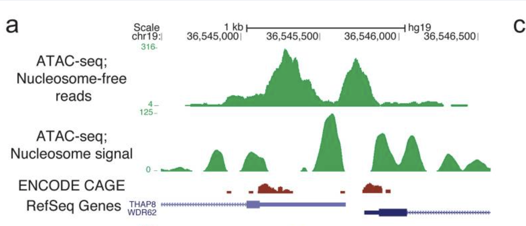

## Evaluating signal over TSS regions.

If our shorter fragments represent the open regions around transcription factors and transcriptional machinery we would expect to see signal at transcriptional start sites.

Our longer fragments will represent signal around nucleosomes and so signal should be outside of the transcriptional start sites and more present at the +1 and -1 nucleosome positions.

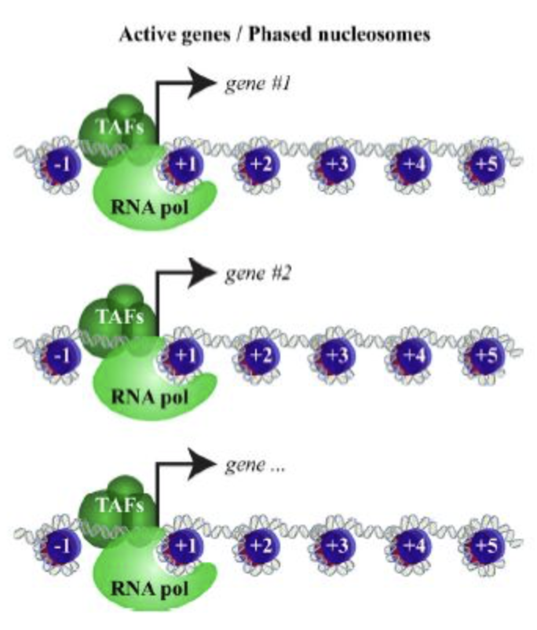

## Evaluating signal over TSS regions.

We can create a meta-plot over all TSS regions to illustrate where our nucleosome free and nucleosome occupied fractions of signal are most prevalent.

Meta-plots average or sum signal over sets of regions to identify trends in data.

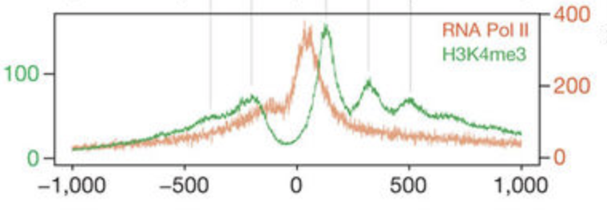

## Plotting signal over regions in R.

To produce meta-plots of signal over regions we can use the **soGGi** bioconductor package. We will be using a development of soGGi however so we will need to install from the github repository.

To install packages from a Github directory we can take advantage of the **install_github()** function in the **devtools** package. The **install_github()** simply takes the **user and repository name** as a file path for library to install.

First we install the **devtools** library.

```r
install.packages("devtools")
library(devtools)
install_github("ThomasCarroll/soGGi")
```

## Plotting signal over regions in R.

Now we have installed the **soGGi** library from github we can load as any standard library.

```r
library(soGGi)
```

## Plotting regions in soGGi.

The soGGi library simply requires a BAM file and a GRanges of regions over which to average signal to produce the meta-plot.

We wish to plot over TSS regions and so we first will need to produce a GRanges of TSS locations for hg19 genome.

Thankfully we now know how to extract these regions for all genes using the **TxDB packages** and some **GenomicRanges** functions.

First we can load our TxDb of interest - **TxDb.Hsapiens.UCSC.hg19.knownGene**.

```r
library(TxDb.Hsapiens.UCSC.hg19.knownGene)
TxDb.Hsapiens.UCSC.hg19.knownGene
```

```
TxDb object:
# Db type: TxDb
# Supporting package: GenomicFeatures
# Data source: UCSC
# Genome: hg19
# Organism: Homo sapiens
# Taxonomy ID: 9606
# UCSC Table: knownGene
# Resource URL: http://genome.ucsc.edu/
# Type of Gene ID: Entrez Gene ID
# Full dataset: yes
# miRBase build ID: GRCh37
# transcript_nrow: 82960
# exon_nrow: 289969
# cds_nrow: 237533
# Db created by: GenomicFeatures package from Bioconductor
# Creation time: 2015-10-07 18:11:28 +0000 (Wed, 07 Oct 2015)
# GenomicFeatures version at creation time: 1.21.30
# RSQLite version at creation time: 1.0.0
# DBSCHEMAVERSION: 1.1
```

## Plotting regions in soGGi.

We can extract gene locations (TSS to TTS) [using the **genes()** function and our **TxDb** object.](https://rockefelleruniversity.github.io/Bioconductor_Introduction/r_course/presentations/slides/GenomicFeatures_In_Bioconductor.html#15)

```r
genesLocations <- genes(TxDb.Hsapiens.UCSC.hg19.knownGene)
genesLocations
```

```
GRanges object with 23056 ranges and 1 metadata column:
        seqnames                 ranges strand |     gene_id
           <Rle>              <IRanges>  <Rle> | <character>
      1    chr19 [ 58858172,  58874214]      - |           1
     10     chr8 [ 18248755,  18258723]      + |          10
    100    chr20 [ 43248163,  43280376]      - |         100
   1000    chr18 [ 25530930,  25757445]      - |        1000
  10000     chr1 [243651535, 244006886]      - |       10000
    ...      ...                    ...    ... .         ...
   9991     chr9 [114979995, 115095944]      - |        9991
   9992    chr21 [ 35736323,  35743440]      + |        9992
   9993    chr22 [ 19023795,  19109967]      - |        9993
   9994     chr6 [ 90539619,  90584155]      + |        9994
   9997    chr22 [ 50961997,  50964905]      - |        9997
  -------
  seqinfo: 93 sequences (1 circular) from hg19 genome
```

# Plotting regions in soGGi.

The soGGi package’s **regionPlot()** function requires a BAM file of data to plot supplied to **bamFile** parameter and a GRanges to plot over supplied to **testRanges** argument.

```r
library(soGGi)
sortedBAM <- "~/Downloads/ATAC_Workshop/ATAC_Data/ATAC_BAM/Sorted_ATAC_50K_2.bam"

library(Rsamtools)
# Nucleosome free
allSignal <- regionPlot(bamFile = sortedBAM,
                        testRanges = tssLocations)
```

## Plotting regions in soGGi.

Now we have our profile object we can create our metaplot using the **plotRegion()** function in **soGGi**.

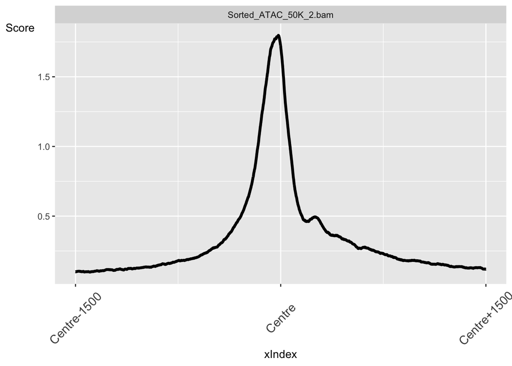

```r
plotRegion(nucFree)
```

## Plotting regions in soGGi.

We can create a plot for our mono-nucleosome signal by adjusting our **minFragmentLength** and **maxFragmentLength** parameters to those expected for nucleosome length fragments (here 180 to 240).

```r
monoNuc <- regionPlot(bamFile = sortedBAM,
                        testRanges = tssLocations,
                        style = "point",
                        format="bam",
                        paired=TRUE,
                        minFragmentLength = 180,maxFragmentLength = 240,forceFragment = 80)
save(monoNuc,file = "../../Data/monoNuc_TSS.RData")
```

# Greenleaf dataset - Finding Open Regions.

A common goal in ATAC-seq is to identify nucleosome free regions where transcription factors are binding and/or transcriptional machinery is active. This nucleosome free signal would correspond to fragments less than one nucleosome (as defined in Greenleaf paper < 100bp)

To identify open chromatin however we could simply use all reads which have been properly paired in sequencing (< 2000bp).

For the remainder of the workshop we will look at analysing the nucleosome free portions of the our ATAC-seq data.

### Single end peak calling.

With single end sequencing from ATAC-seq we do not know how long the fragments are.

To identify open regions therefore requires some different parameters for MACS2 peak calling.

One strategy employed is to shift read 5’ ends by -100 and then extend from this by 200bp. Considering the expected size of our nucleosome free fragments this should provide a pile-up over nucelosome regions suitable for MACS2 window size.

```bash
MACS2 callpeak -t singleEnd.bam --nomodel --shift -100
                --extsize 200 --format BAM -g MyGenome
```

Alternatively for the nucleosome occupied data we can adjust shift and extension to centre the signal on nucleosome centres (nucleosomes wrapped in 147bp of DNA).

```bash
MACS2 callpeak -t singleEnd.bam --nomodel --shift 37
               --extsize 73 --format BAM -g MyGenome
```

For our pair-end data here, we call peaks on our nucleosome free regions from our nucleosome free region BAM file.

```bash
MACS2 callpeak  -t ~/Downloads/Sorted_ATAC_50K_2_openRegions.bam
                --outdir ATAC_Data/ATAC_Peaks/ATAC_50K_2
                --name Sorted_ATAC_50K_2_Small_Paired_peaks.narrowPeak
                -f BAMPE -g hs
```

## QC for low quality, duplicates and signal distribution.

Before we remove any data we can get a quick assessment of our reads in peaks, duplication rate, low quality reads and reads in artefact regions from ChIPQC.

```r
library(ChIPQC)
library(rtracklayer)
library(DT)
library(dplyr)
library(tidyr)

blkList <- import.bed("../../Data/ENCFF001TDO.bed.gz")
openRegionPeaks <- "../../Data/Sorted_ATAC_50K_2_Small_Paired_peaks.narrowPeak"

qcRes <- ChIPQCsample("~/Downloads/ATAC_Workshop/ATAC_Data/ATAC_BAM/Sorted_ATAC_50K_2_openRegions.bam",
                      peaks = openRegionPeaks,
                      annotation ="hg19",
                      chromosomes = "chr20",
                      blacklist = blkList,
                      verboseT = FALSE)
save(qcRes,file="../../Data/qcRes.RData")
```

## Remove blacklisted peaks

Since blacklisted regions may confound our analysis we remove any peaks which have been called there.

Removing blacklists too early can hide some of the qc issues in your data. The **blacklist** should always be considered in your analysis and recommended to removed data from these regions once QC is considered.

```r
MacsCalls <- granges(qcRes[seqnames(qcRes) %in% "chr20"])

data.frame(Blacklisted=sum(MacsCalls %over% blkList),
           Not_Blacklisted=sum(!MacsCalls %over% blkList))
```

```
  Blacklisted Not_Blacklisted
1           2             596
```

```r
MacsCalls <- MacsCalls[!MacsCalls %over% blkList]
```

# Greenleaf dataset - Annotating Open Regions.

It is often of interest to associate identified nucleosome free regions to genomic features such as genes and enhancers.

Once annotated to genes or enhancers’ genes, we can start to associate ATAC-seq data to characteristics of these genes. (functional annotation, expression changes, other epigenetic states)

### Displaying annotation distribution

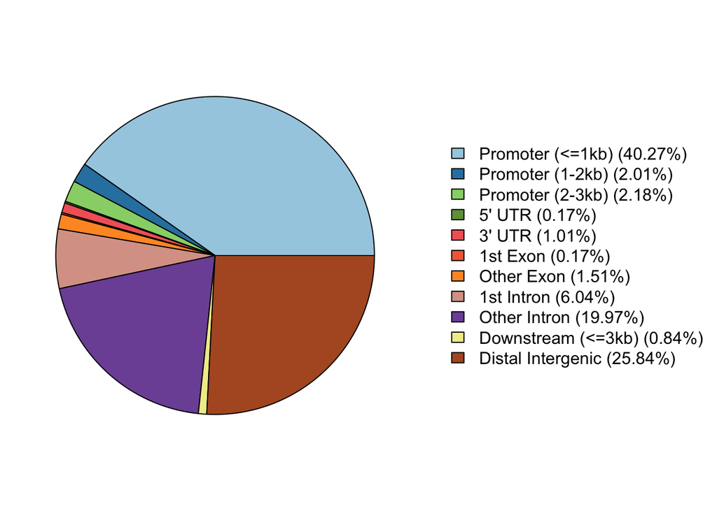

```r
plotAnnoPie(MacsCalls_Anno)
```

### Retrieving annotated Nucleosome-free regions.

With this information we can then subset our peaks/nuc free regions to those only landing in TSS regions (+/- 500)

```r
MacsGR_Anno <- as.GRanges(MacsCalls_Anno)
MacsGR_TSS <-   MacsGR_Anno[abs(MacsGR_Anno$distanceToTSS) < 500]
MacsGR_TSS[1,]
```

```
GRanges object with 1 range and 9 metadata columns:
      seqnames           ranges strand |       annotation   geneChr
         <Rle>        <IRanges>  <Rle> |      <character> <integer>
  [1]    chr20 [278001, 278160]      * | Promoter (<=1kb)        20
      geneStart   geneEnd geneLength geneStrand      geneId transcriptId
      <integer> <integer>  <integer>  <integer> <character>  <character>
  [1]    278204    280963       2760          1       85364   uc002wdf.3
      distanceToTSS
          <numeric>
  [1]           -44
  -------
  seqinfo: 1 sequence from hg19 genome
```

### Functional Analysis of Nucleosome-free regions - 1.

We can submit our peak calls to GREAT using the **submitGreatJob** function and review available categories of results using **availableCategories**.

```r
library(rGREAT)
great_Job <- submitGreatJob(MacsCalls, species = "hg19")
availableCategories(great_Job)
```

```
[1] "GO"                               "Phenotype Data and Human Disease"
[3] "Pathway Data"                     "Gene Expression"
[5] "Regulatory Motifs"                "Gene Families"
```

## Differential ATAC-seq

We have briefly reviewed the processing and initial analysis of one ATAC-seq sample using R.

In the next part we will look at how we can identify changes in open regions using R/Bioconductor.

Here we will take an approach akin that in Diffbind and reasonably esatablished in ATAC-seq analysis.

## Identifying a set of non-redundant peaks.

```r
allPeaksSet_nR[1:2,]
```

```
GRanges object with 2 ranges and 6 metadata columns:
      seqnames             ranges strand |
         <Rle>          <IRanges>  <Rle> |
  [1]     chr1 [3130336, 3130413]      * |
  [2]     chr1 [3400112, 3400250]      * |
      Sorted_Hindbrain_day_12_1_Small_Paired_peaks.narrowPeak
                                                    <logical>
  [1]                                                   FALSE
  [2]                                                   FALSE
      Sorted_Hindbrain_day_12_2_Small_Paired_peaks.narrowPeak
                                                    <logical>
  [1]                                                   FALSE
  [2]                                                   FALSE
      Sorted_Kidney_day_15_1_Small_Paired_peaks.narrowPeak
                                                 <logical>
  [1]                                                FALSE
  [2]                                                FALSE
      Sorted_Kidney_day_15_2_Small_Paired_peaks.narrowPeak
                                                 <logical>
  [1]                                                 TRUE
  [2]                                                 TRUE
      Sorted_Liver_day_12_1_Small_Paired_peaks.narrowPeak
                                                <logical>
  [1]                                               FALSE
  [2]                                               FALSE
      Sorted_Liver_day_12_2_Small_Paired_peaks.narrowPeak
                                                <logical>
  [1]                                               FALSE
  [2]                                               FALSE
  -------
  seqinfo: 22 sequences from an unspecified genome; no seqlengths
```

# Counting for differential ATAC-seq.

```r
library(Rsubread)
occurrences <- rowSums(
  as.data.frame(elementMetadata(nrToCount)
                )
  )

nrToCount <- nrToCount[occurrences >= 2,]
nrToCount
```

```
GRanges object with 36320 ranges and 6 metadata columns:
          seqnames               ranges strand |
             <Rle>            <IRanges>  <Rle> |
      [1]     chr1   [3433954, 3434095]      * |
      [2]     chr1   [3575895, 3576078]      * |
      [3]     chr1   [3671534, 3671885]      * |
      [4]     chr1   [3994858, 3995006]      * |
      [5]     chr1   [4560267, 4560344]      * |
      ...      ...                  ...    ... .
  [36316]     chrY [90784207, 90784298]      * |
  [36317]     chrY [90784944, 90785099]      * |
  [36318]     chrY [90801504, 90801651]      * |
  [36319]     chrY [90807391, 90807562]      * |
  [36320]     chrY [90812961, 90813237]      * |
          Sorted_Hindbrain_day_12_1_Small_Paired_peaks.narrowPeak
```

[output cut: 79 more lines]

## DESeq2 for differential ATAC-seq.

With our counts of fragments in nucleosome free regions we can now contruct a DESeq2 object.

We pass the GRanges of regions we count to DESeqDataSetFromMatrix function so as to access these from DESeq2 later.

```r
library(DESeq2)
load("../../Data/myCounts.RData")
Group <- factor(c("HindBrain","HindBrain","Kidney","Kidney",
                  "Liver","Liver"))
metaData <- data.frame(Group,row.names=colnames(myCounts))

atacDDS <- DESeqDataSetFromMatrix(assay(myCounts),
                                  metaData,
                                  ~Group,
                                  rowRanges=rowRanges(myCounts))
atacDDS <- DESeq(atacDDS)
```

## DESeq2 for differential ATAC-seq.

We can subset to only open regions within promoters and then create a table to review the results in IGV using makebedtable function in tracktables package.

```r
library(TxDb.Mmusculus.UCSC.mm10.knownGene)
toOverLap <- promoters(TxDb.Mmusculus.UCSC.mm10.knownGene,
                       500,500)
KidneyMinusHindbrain <- KidneyMinusHindbrain[
                          (!is.na(KidneyMinusHindbrain$padj)
                           & KidneyMinusHindbrain$padj < 0.05)
                           & KidneyMinusHindbrain %over% toOverLap,]
makebedtable(KidneyMinusHindbrain,"KidneyMinusHindbrain.html",getwd())
```

```
[1] "/Users/tcarroll/Projects/Software/Github/RU_ATACseq/atacseq_course/Presentations/Slides/KidneyMinusHindbrain.html"
```

## Annotation for differential ATAC-seq.

Since we have subset regions to those within +/- 500bp of a TSS we can use a standard enrichment analysis at this point. Here we use clusterProfiler to identify enrichment

```r
library(clusterProfiler)
go <- enrichGO(DB_ATAC$geneId,
                OrgDb = "org.Mm.eg.db",ont = "BP",maxGSSize = 5000)
go[1:2,1:6]
```

```
                   ID                                      Description
GO:0051494 GO:0051494 negative regulation of cytoskeleton organization
GO:0007399 GO:0007399                       nervous system development
           GeneRatio    BgRatio       pvalue     p.adjust
GO:0051494    19/441  128/23454 3.694502e-12 8.907243e-09
GO:0007399    87/441 2164/23454 7.081771e-12 8.907243e-09
```

## Finding motifs

We need to identify the position of CTCF motifs across the genome so first we need to know what a CTCF motif looks like.

The motifDB package contains information on Motifs from public databases such as Jaspar. Here we use the **query()** function with our motif of interest (**CTCF**) to extract the CTCF motif.

```r
library(MotifDb)
library(Biostrings)
library(BSgenome.Hsapiens.UCSC.hg19)
CTCF <- query(MotifDb, c("CTCF"))
CTCF
```

```
MotifDb object of length 4
| Created from downloaded public sources: 2013-Aug-30
| 4 position frequency matrices from 3 sources:
|        JASPAR_2014:    2
|        JASPAR_CORE:    1
|          jolma2013:    1
| 2 organism/s
|           Hsapiens:    3
|      Dmelanogaster:    1
Hsapiens-JASPAR_CORE-CTCF-MA0139.1
Hsapiens-JASPAR_2014-CTCF-MA0139.1
Dmelanogaster-JASPAR_2014-CTCF-MA0531.1
Hsapiens-jolma2013-CTCF
```

## Visualising PWMs

We can visualise the frequency of DNA bases in our motif using the **seqLogo** package and the **seqLogo** function.

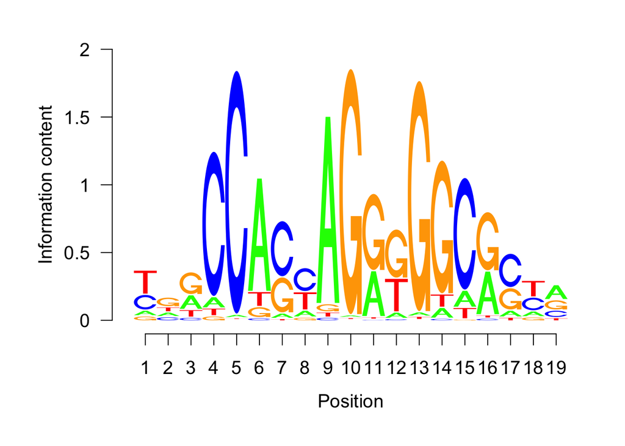

```r
library(seqLogo)
seqLogo(ctcfMotif)
```

## Searching for PWMs in DNAstring.

We can now use the **matchPWM()** function with our newly acquired CTCF PWM.

Here we will search the sequence on Chr20 using the sequence provided within the BSgenome library for human **BSgenome.Hsapiens.UCSC.hg19**.

```r
myRes <- matchPWM(ctcfMotif,BSgenome.Hsapiens.UCSC.hg19[["chr20"]])
myRes
```

```
  Views on a 63025520-letter DNAString subject
subject: NNNNNNNNNNNNNNNNNNNNNNNNNNNNNNNN...NNNNNNNNNNNNNNNNNNNNNNNNNNNNNNN
views:
          start      end width
   [1]   239773   239791    19 [TTGCCACTGGGGGGAGACA]
   [2]   246577   246595    19 [CAGCCCCCAGGTGGCAGCC]
   [3]   335282   335300    19 [GTACCACTAGAGGGAGCTC]
   [4]   360674   360692    19 [TCACCACTAGGCCGCACTG]
   [5]   413626   413644    19 [TTGGCAGCAGGGGCCACCA]
   ...      ...      ...   ... ...
[1530] 62917490 62917508    19 [GCGCCAGCAGGGGGCGCTG]
[1531] 62917548 62917566    19 [TCGCCAGCAGGGGGTGCAC]
[1532] 62917607 62917625    19 [CTGCAAGCAGGGGGCGGTC]
[1533] 62922628 62922646    19 [GCACCAGAAGGTGGCAGGA]
[1534] 62922894 62922912    19 [GATCCAGCAAGGGGCGGCA]
```

## Searching for PWMs in DNAstring.

We need to convert the Views object to a GRanges so we can use these in soGGi to plot cut sites over.

```r
toCompare <- GRanges("chr20",ranges(myRes))
toCompare
```

```
GRanges object with 1534 ranges and 0 metadata columns:
         seqnames               ranges strand
            <Rle>            <IRanges>  <Rle>
     [1]    chr20     [239773, 239791]      *
     [2]    chr20     [246577, 246595]      *
     [3]    chr20     [335282, 335300]      *
     [4]    chr20     [360674, 360692]      *
     [5]    chr20     [413626, 413644]      *
     ...      ...                  ...    ...
  [1530]    chr20 [62917490, 62917508]      *
  [1531]    chr20 [62917548, 62917566]      *
  [1532]    chr20 [62917607, 62917625]      *
  [1533]    chr20 [62922628, 62922646]      *
  [1534]    chr20 [62922894, 62922912]      *
  -------
  seqinfo: 1 sequence from an unspecified genome; no seqlengths
```

## Shifting reads for cut-sites.

To plot cut-sites we will wish to consider only the 5’ end of reads and will need to adjust for a known offset of 5’ reads to actual T5 cut-sites.

This will involve capturing the 5’end of reads and shifting reads on positive and negative strand by 4bp or -5bp respectively.

First we read in our nucleosome free region BAM file and extract read pairs.

```r
BAM <- "~/Downloads/ATAC_Workshop/ATAC_Data/ATAC_BAM/Sorted_ATAC_50K_2_openRegions.bam"
atacReads_Open <- readGAlignmentPairs(BAM)
read1 <- first(atacReads_Open)
read2 <- second(atacReads_Open)
read2[1,]
```

```
GAlignments object with 1 alignment and 0 metadata columns:
      seqnames strand       cigar    qwidth     start       end     width
         <Rle>  <Rle> <character> <integer> <integer> <integer> <integer>
  [1]    chr20      -         50M        50     60446     60495        50
          njunc
      <integer>
  [1]         0
  -------
  seqinfo: 25 sequences from an unspecified genome
```

## Shifting reads for cut-sites.

Now we can shift the 5’ end of both reads pairs by 4bp or -5bp depending on strand. This produces a GRanges of all our cut-sites from both reads.

```r
Firsts <- resize(granges(read1),fix="start",1)
First_Pos_toCut <- shift(granges(Firsts[strand(read1) == "+"]),
                                         4)
First_Neg_toCut <- shift(granges(Firsts[strand(read1) == "-"]),
                                         -5)

Seconds <- resize(granges(read2),fix="start",1)
Second_Pos_toCut <- shift(granges(Seconds[strand(read2) == "+"]),
                                4)
Second_Neg_toCut <- shift(granges(Seconds[strand(read2) == "-"]),
                                -5)

test_toCut <- c(First_Pos_toCut,First_Neg_toCut,
                Second_Pos_toCut,Second_Neg_toCut)
test_toCut[1:2,]
```

```
GRanges object with 2 ranges and 0 metadata columns:
      seqnames         ranges strand
         <Rle>      <IRanges>  <Rle>
  [1]    chr20 [60440, 60440]      +
  [2]    chr20 [60490, 60490]      -
  -------
  seqinfo: 25 sequences from an unspecified genome
```

## Coverage for cut-sites.

Now we can use the GRanges of cut-site positions to produce an RLElist of cut-sites across the genome using the **coverage()** function.

```r
cutsCoverage <- coverage(test_toCut)
cutsCoverage20 <- cutsCoverage["chr20"]
cutsCoverage20[[1]]
```

```
integer-Rle of length 63025520 with 109971 runs
  Lengths: 60439     1    49     1  1465 ...   561     1  5268     1 60295
  Values :     0     1     0     2     0 ...     0     1     0     1     0
```

## Plotting for cut-sites.

We can use an RLElist with soGGi to produce a plot of cut-sites around our discovered CTCF motifs.

We change the **format** to rlelist and the **distanceAround** parameter to 500bp.

```r
CTCF_Cuts_open <- regionPlot(cutsCoverage20,
                         testRanges = toCompare,
                         style = "point",
                         format="rlelist",distanceAround = 500)
```

## Plotting for cut-sites.

Now we can now plot our cut-sites using the **plotRegion()** function.

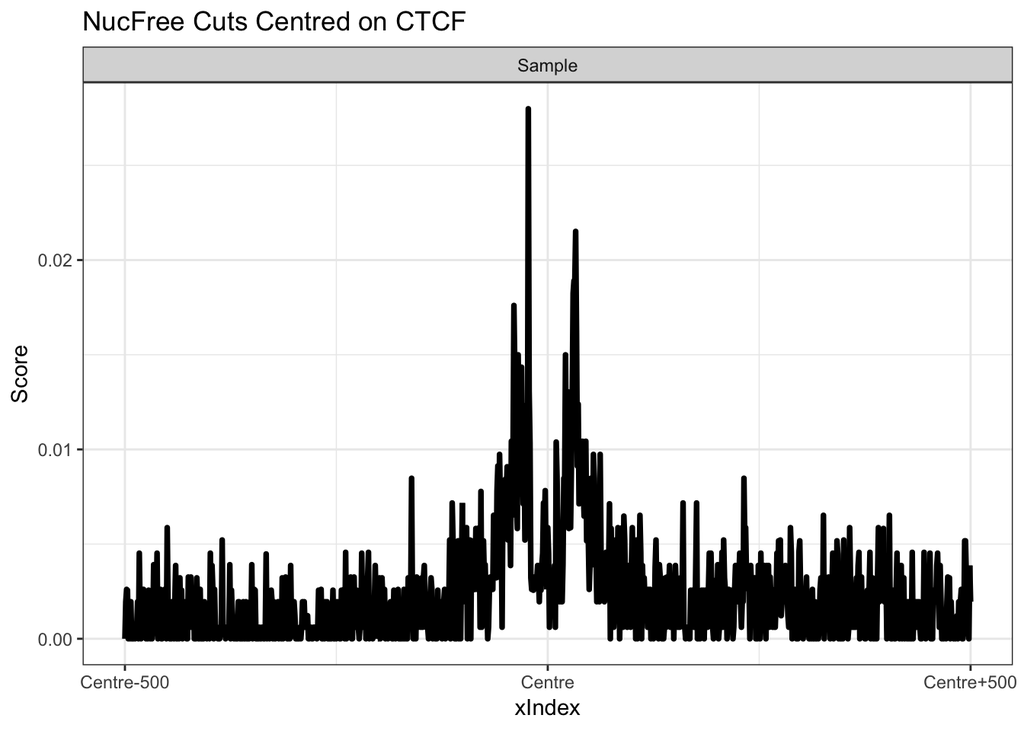

```r
plotRegion(CTCF_Cuts_open,outliers = 0.001)+
  ggtitle("NucFree Cuts Centred on CTCF")+theme_bw()
```

# Time for an exercise.

Link_to_exercises

Link_to_answers